# Initial Information

1. Title: Glass Identification Database
2. Sources: (a) Creator: B. German

   ```
    -- Central Research Establishment
       Home Office Forensic Science Service
       Aldermaston, Reading, Berkshire RG7 4PN
   ```

   (b) Donor: Vina Spiehler, Ph.D., DABFT

   ```
           Diagnostic Products Corporation
           (213) 776-0180 (ext 3014)
   ```

   (c) Date: September, 1987
3. Past Usage: -- Rule Induction in Forensic Science

   ```
   -- Ian W. Evett and Ernest J. Spiehler
   -- Central Research Establishment
      Home Office Forensic Science Service
      Aldermaston, Reading, Berkshire RG7 4PN
   -- Unknown technical note number (sorry, not listed here)
   -- General Results: nearest neighbor held its own with respect to the
         rule-based system
   ```

4. Relevant Information:n Vina conducted a comparison test of her rule-based system, BEAGLE, the nearest-neighbor algorithm, and discriminant analysis. BEAGLE is a product available through VRS Consulting, Inc.; 4676 Admiralty Way, Suite 206; Marina Del Ray, CA 90292 (213) 827-7890 and FAX: -3189. In determining whether the glass was a type of "float" glass or not, the following results were obtained (# incorrect answers):

   ```
         Type of Sample                            Beagle   NN    DA
         Windows that were float processed (87)     10      12    21
         Windows that were not:            (76)     19      16    22
   ```

   The study of classification of types of glass was motivated by criminological investigation. At the scene of the crime, the glass left can be used as evidence...if it is correctly identified!
5. Number of Instances: 214
6. Number of Attributes: 10 (including an Id#) plus the class attribute -- all attributes are continuously valued
7. Attribute Information:
   1. Id number: 1 to 214
   2. RI: refractive index
   3. Na: Sodium (unit measurement: weight percent in corresponding oxide, as

      ```
              are attributes 4-10)
      ```

   4. Mg: Magnesium
   5. Al: Aluminum
   6. Si: Silicon
   7. K: Potassium
   8. Ca: Calcium
   9. Ba: Barium
   10. Fe: Iron
   11. Type of glass: (class attribute) -- 1 building_windows_float_processed -- 2 building_windows_non_float_processed -- 3 vehicle_windows_float_processed -- 4 vehicle_windows_non_float_processed (none in this database) -- 5 containers -- 6 tableware -- 7 headlamps
8. Missing Attribute Values: None

Summary Statistics: Attribute: Min Max Mean SD Correlation with class

1. RI: 1.5112 1.5339 1.5184 0.0030 -0.1642
2. Na: 10.73 17.38 13.4079 0.8166 0.5030
3. Mg: 0 4.49 2.6845 1.4424 -0.7447
4. Al: 0.29 3.5 1.4449 0.4993 0.5988
5. Si: 69.81 75.41 72.6509 0.7745 0.1515
6. K: 0 6.21 0.4971 0.6522 -0.0100
7. Ca: 5.43 16.19 8.9570 1.4232 0.0007
8. Ba: 0 3.15 0.1750 0.4972 0.5751
   1. Fe: 0 0.51 0.0570 0.0974 -0.1879
1. Class Distribution: (out of 214 total instances) -- 163 Window glass (building windows and vehicle windows)

   ```
   -- 87 float processed
      -- 70 building windows
      -- 17 vehicle windows
   -- 76 non-float processed
      -- 76 building windows
      -- 0 vehicle windows
   ```

   -- 51 Non-window glass

   ```
   -- 13 containers
   -- 9 tableware
   -- 29 headlamps
   ```

dataset source : https://archive.ics.uci.edu/ml/datasets/Glass+Identification

# Load Libraries

```python
import pandas as pd
import numpy as np
import matplotlib.pyplot as plt
import seaborn as sns
```

```python
from warnings import filterwarnings
filterwarnings("ignore")
```

# Load Dataset

```python
# load dataset & set header by None since our dataset didnt have name of column
data = pd.read_csv('E:/project_py_web/FREELANCER/Glass Classification_/glass_data.csv', header=None)
```

# Exploratory Data Analysis

Perform an initial analysis of the data (EDA) using python in your Jupyter notebook. Discuss your findings and what relevance they might have on your planned Neural Network model.

```python
# replace numerical column name into some columns name mention in project file
data.columns = ["Id", "RI", "Na", "Mg", "Al", "Si", "K", "Ca", "Ba", "Fe", "Class"]
```

```python
# drop column Id because not related to any information
data = data.drop("Id", axis=1)
```

```python
# show 5 random row of dataset
data.sample(5)
```

|  | RI | Na | Mg | Al | Si | K | Ca | Ba | Fe | Class |
| --- | --- | --- | --- | --- | --- | --- | --- | --- | --- | --- |
| 97 | 1.51743 | 12.20 | 3.25 | 1.16 | 73.55 | 0.62 | 8.90 | 0.00 | 0.24 | 2 |
| 140 | 1.51690 | 13.33 | 3.54 | 1.61 | 72.54 | 0.68 | 8.11 | 0.00 | 0.00 | 2 |
| 186 | 1.51838 | 14.32 | 3.26 | 2.22 | 71.25 | 1.46 | 5.79 | 1.63 | 0.00 | 7 |
| 38 | 1.52213 | 14.21 | 3.82 | 0.47 | 71.77 | 0.11 | 9.57 | 0.00 | 0.00 | 1 |
| 170 | 1.52369 | 13.44 | 0.00 | 1.58 | 72.22 | 0.32 | 12.24 | 0.00 | 0.00 | 5 |

```python
# show total row & column of dataset
data.shape
```

```
(214, 10)
```

```python
# finding information of statistic feature
data.describe()
```

|  | RI | Na | Mg | Al | Si | K | Ca | Ba | Fe | Class |
| --- | --- | --- | --- | --- | --- | --- | --- | --- | --- | --- |
| count | 214.000000 | 214.000000 | 214.000000 | 214.000000 | 214.000000 | 214.000000 | 214.000000 | 214.000000 | 214.000000 | 214.000000 |
| mean | 1.518365 | 13.407850 | 2.684533 | 1.444907 | 72.650935 | 0.497056 | 8.956963 | 0.175047 | 0.057009 | 2.780374 |
| std | 0.003037 | 0.816604 | 1.442408 | 0.499270 | 0.774546 | 0.652192 | 1.423153 | 0.497219 | 0.097439 | 2.103739 |
| min | 1.511150 | 10.730000 | 0.000000 | 0.290000 | 69.810000 | 0.000000 | 5.430000 | 0.000000 | 0.000000 | 1.000000 |
| 25% | 1.516523 | 12.907500 | 2.115000 | 1.190000 | 72.280000 | 0.122500 | 8.240000 | 0.000000 | 0.000000 | 1.000000 |
| 50% | 1.517680 | 13.300000 | 3.480000 | 1.360000 | 72.790000 | 0.555000 | 8.600000 | 0.000000 | 0.000000 | 2.000000 |
| 75% | 1.519157 | 13.825000 | 3.600000 | 1.630000 | 73.087500 | 0.610000 | 9.172500 | 0.000000 | 0.100000 | 3.000000 |
| max | 1.533930 | 17.380000 | 4.490000 | 3.500000 | 75.410000 | 6.210000 | 16.190000 | 3.150000 | 0.510000 | 7.000000 |

```python
# check if column contain NaN / Blank values or not
data.isna().sum()
```

```
RI       0
Na       0
Mg       0
Al       0
Si       0
K        0
Ca       0
Ba       0
Fe       0
Class    0
dtype: int64
```

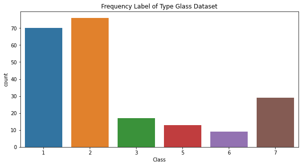

```python
# show frequency of each class in glass dataset
plt.figure(figsize=(10,5))
sns.countplot(data.Class).set_title("Frequency Label of Type Glass Dataset");
```

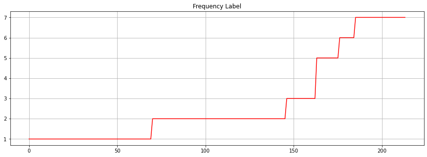

```python
# show visualisation of label
data["Class"].plot(color="red", legend=False, grid=True, figsize=(15,5), title="Frequency Label");
```

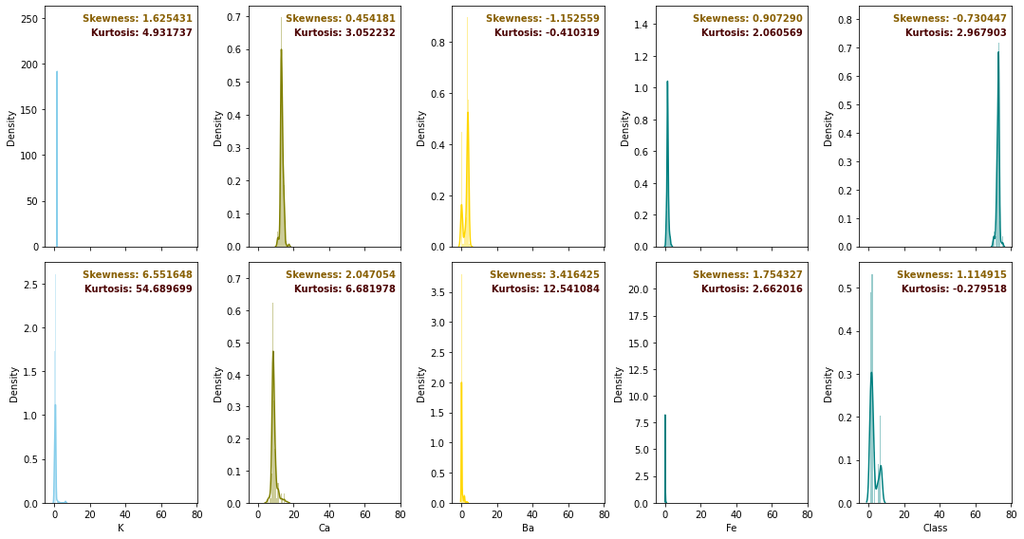

```python
# check skewness for each feature
f, axes = plt.subplots(2, 5, figsize=(15, 8), sharex=True)
sns.distplot(data.iloc[:,0], color="skyblue", ax=axes[0,0])
sns.distplot(data.iloc[:,1], color="olive", ax=axes[0,1])
sns.distplot(data.iloc[:,2], color="gold", ax=axes[0,2])
sns.distplot(data.iloc[:,3], color="teal", ax=axes[0,3])
sns.distplot(data.iloc[:,4], color="teal", ax=axes[0,4])
sns.distplot(data.iloc[:,5], color="skyblue", ax=axes[1,0])
sns.distplot(data.iloc[:,6], color="olive", ax=axes[1,1])
sns.distplot(data.iloc[:,7], color="gold", ax=axes[1,2])
sns.distplot(data.iloc[:,8], color="teal", ax=axes[1,3])
sns.distplot(data.iloc[:,9], color="teal", ax=axes[1,4])
for i, ax in enumerate(axes.reshape(-1)):
    ax.text(x=0.97, y=0.97, transform=ax.transAxes, s="Skewness: %f" % data.iloc[:,i].skew(),\
        fontweight='demibold', fontsize=10, verticalalignment='top', horizontalalignment='right',\
        backgroundcolor='white', color='xkcd:poo brown')
    ax.text(x=0.97, y=0.91, transform=ax.transAxes, s="Kurtosis: %f" % data.iloc[:,i].kurt(),\
        fontweight='demibold', fontsize=10, verticalalignment='top', horizontalalignment='right',\
        backgroundcolor='white', color='xkcd:dried blood')
plt.tight_layout()
```

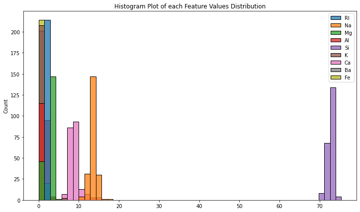

```python
plt.figure(figsize=(12,7))
sns.histplot(data.drop("Class", axis=1)).set_title("Histogram Plot of each Feature Values Distribution");
```

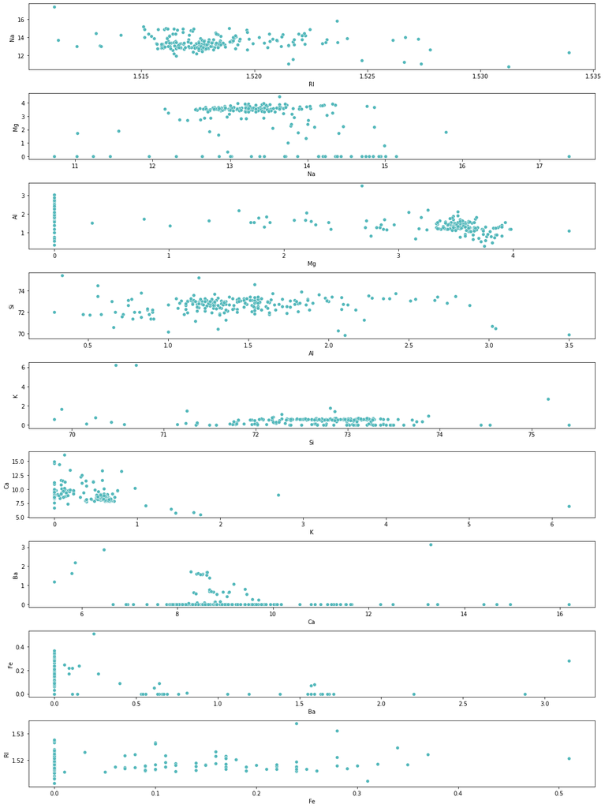

```python
fig, ax = plt.subplots(len(data.columns.tolist()[:9]),1,figsize=(15,20))
feature = data.columns.tolist()[:9]
for i,state in enumerate(data.columns.tolist()[:9]):
    try :
        sns.scatterplot(data=data, x=feature[i], y=feature[i+1],ax=ax[i], color="#53B8BB")
    except :
        sns.scatterplot(data=data, x=feature[i], y=feature[0],ax=ax[i], color="#53B8BB")
    fig.tight_layout()
```

This data analysis exploration stage is one of the important steps in determining the various methods that will be used in the next process in order to obtain good neural network model results for the type of supervised dataset. based on the results of the insight that I got, there were various important points that were found at this stage, such as the csv dataset initially did not have a column name so I had to change the column to a name that matched the one listed in the project attachment, then because the Id feature meant the same thing as the index makes there are 2 information in 1 dataset so I delete the Id column.

# Data Preparation

```python
# overview dataset
data.head(3)
```

|  | RI | Na | Mg | Al | Si | K | Ca | Ba | Fe | Class |
| --- | --- | --- | --- | --- | --- | --- | --- | --- | --- | --- |
| 0 | 1.52101 | 13.64 | 4.49 | 1.10 | 71.78 | 0.06 | 8.75 | 0.0 | 0.0 | 1 |
| 1 | 1.51761 | 13.89 | 3.60 | 1.36 | 72.73 | 0.48 | 7.83 | 0.0 | 0.0 | 1 |
| 2 | 1.51618 | 13.53 | 3.55 | 1.54 | 72.99 | 0.39 | 7.78 | 0.0 | 0.0 | 1 |

```python
# load some libraries
from sklearn.preprocessing import StandardScaler
from sklearn.model_selection import train_test_split
# from sklearn.svm import SVC
# from sklearn.feature_selection import RFE
```

```python
# define feature training & feature target
X = data.iloc[:, :9]
X = np.cbrt(X) # Cube root transformation to handle skewness
Y = data.iloc[:, -1]
Y = Y.map({1:0,2:1,3:2,5:3,6:4,7:5})
```

```python
# define scaler function
scaler = StandardScaler().fit(X) # change our feature training data from un-ordered value become value in range 0-1
```

The ML algorithm is sensitive to the “relative scales of features,” which usually happens when it uses the numeric values of the features rather than say their rank. In many algorithms, when we desire faster convergence, scaling is a MUST like in Neural Network. Since the range of values of raw data varies widely, in some machine learning algorithms, objective functions do not work correctly without normalization. For example, the majority of classifiers calculate the distance between two points by the distance. If one of the features has a broad range of values, the distance governs this particular feature. Therefore, the range of all features should be normalized so that each feature contributes approximately proportionately to the final distance.

```python
# apply feature scaling to our training feature
X_norm = scaler.transform(X)
```

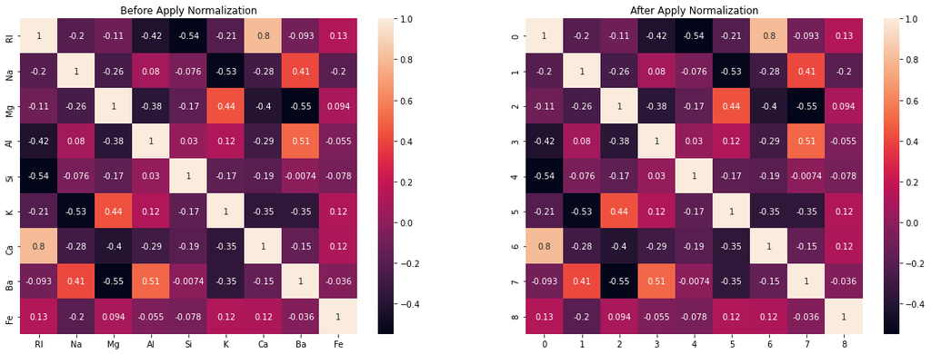

```python
# compare correlation feature before and after apply feature scaling
fig, ax = plt.subplots(1, 2, figsize=(20,7))
sns.heatmap(X.corr(), annot=True, ax=ax[0]).set_title("Before Apply Normalization")
sns.heatmap(pd.DataFrame(X_norm).corr(), annot=True, ax=ax[1]).set_title("After Apply Normalization")
plt.show()
```

Separating data into training and testing sets is an important part of evaluating data mining models. Typically, when you separate a data set into a training set and testing set, most of the data is used for training, and a smaller portion of the data is used for testing. Analysis Services randomly samples the data to help ensure that the testing and training sets are similar. By using similar data for training and testing, you can minimize the effects of data discrepancies and better understand the characteristics of the model. After a model has been processed by using the training set, you test the model by making predictions against the test set. Because the data in the testing set already contains known values for the attribute that you want to predict, it is easy to determine whether the model's guesses are correct.

```python
# split dataset for training model with ratio 80% for training, 20% for testing
X_train, X_test, y_train, y_test = train_test_split(X_norm, Y, test_size=0.2, random_state=1, stratify=Y)
```

# Implemented Neural Network

```python
# pip install visualkeras
```

```python
import visualkeras
from tensorflow.keras.models import Sequential
from tensorflow.keras.layers import Dense,Dropout
from tensorflow.keras.callbacks import EarlyStopping
```

```python
# here im create Artificial Neural Network base on tensorflow & keras package
```

The softmax function is used as the activation function in the output layer of neural network models that predict a multinomial probability distribution. That is, softmax is used as the activation function for multi-class classification problems where class membership is required on more than two class labels.

The rectified linear activation function or ReLU for short is a piecewise linear function that will output the input directly if it is positive, otherwise, it will output zero. The rectified linear activation function overcomes the vanishing gradient problem, allowing models to learn faster and perform better.

```python
# define sequantial layers
model = Sequential()
# add dense layer with activation function relu & softmax with input dims -> 9
model.add(Dense(45, activation="relu", input_dim=9))
model.add(Dense(30, activation="relu"))
model.add(Dense(25, activation="relu"))
model.add(Dense(22, activation="relu"))
model.add(Dense(18, activation="relu"))
model.add(Dense(15, activation="relu"))
model.add(Dense(10, activation="relu"))
model.add(Dense(8, activation="relu"))
# output layer with output dims -> 6
model.add(Dense(6, activation="softmax"))
```

Adam is a replacement optimization algorithm for stochastic gradient descent for training deep learning models. Adam combines the best properties of the AdaGrad and RMSProp algorithms to provide an optimization algorithm that can handle sparse gradients on noisy problems.

Sparse Categorical Accuracy calculates the percentage of records for which the integer targets (yTrue) are in the top K predictions (yPred). If the rank of the yPred present in the index of the non zero yTrue is less than or equal to K, it is considered accurate.

```python
model.compile(optimizer="adam", loss="sparse_categorical_crossentropy", metrics=["acc"])
```

```python
# model architecture
model.summary()
```

```
Model: "sequential_3"
_________________________________________________________________
Layer (type)                 Output Shape              Param #
=================================================================
dense_27 (Dense)             (None, 45)                450
_________________________________________________________________
dense_28 (Dense)             (None, 30)                1380
_________________________________________________________________
dense_29 (Dense)             (None, 25)                775
_________________________________________________________________
dense_30 (Dense)             (None, 22)                572
_________________________________________________________________
dense_31 (Dense)             (None, 18)                414
_________________________________________________________________
dense_32 (Dense)             (None, 15)                285
_________________________________________________________________
dense_33 (Dense)             (None, 10)                160
_________________________________________________________________
dense_34 (Dense)             (None, 8)                 88
_________________________________________________________________
dense_35 (Dense)             (None, 6)                 54
=================================================================
Total params: 4,178
Trainable params: 4,178
Non-trainable params: 0
_________________________________________________________________
```

Insight About Artificial Neural Network :

```
    An artificial neural net is an information processing paradigm whose working is similar to the working of biological nervous systems. The key element of an artificial neural network is the novel structure of its information processing system. This structure consists of a large number of highly interconnected processing computing elements that work in unison to solve specific problems.

Artificial neural networks can learn by example like the way humans do. An artificial neural net is configured for a specific application like pattern recognition through a learning process. Learning in biological systems consists of adjustments to the synaptic connections that exist between neurons. This is true of artificial neural networks as well. Artificial neural networks can be applied to an increasing number of real-world problems of considerable complexity. They are used for solving problems that are too complex for conventional technologies or those types of problems that do not have an algorithmic solution.
```

Benefit Using This Type of Neural Network:

```
- Neural networks can learn organically. This means an artificial neural network’s outputs aren't limited entirely by inputs and results given to them initially by an expert system. Artificial neural networks have the ability to generalize their inputs. This ability is valuable for robotics and pattern recognition systems.

- Nonlinear systems have the capability of finding shortcuts to reach computationally expensive solutions. These systems can also infer connections between data points, rather than waiting for records in a data source to be explicitly linked. This nonlinear short-cut mechanism is fed into artificial neural networking, which makes it valuable in commercial big-data analysis.

- Artificial neural networks have the potential for high fault tolerance. When these networks are scaled across multiple machines and multiple servers, they are able to route around missing data or servers and nodes that can't communicate.

- Artificial neural networks can do more than routing around parts of the network that no longer operate. If they are asked for finding out specific data that is no longer communicating, these artificial neural networks can regenerate large amounts of data by inference and help in determining the node that is not working. This trait is useful for networks that require informing their users about the current state of the network and effectively results in a self-debugging and diagnosing network.
```

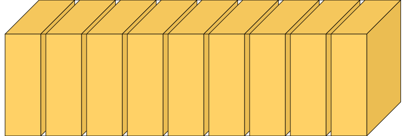

```python
visualkeras.layered_view(model, min_xy=200, min_z=70)
```

```python
es = EarlyStopping(monitor='loss', mode="min", patience=5)
```

```python
# training model
history = model.fit(X_train, y_train, validation_data=(X_test, y_test), callbacks=es, epochs=300, batch_size=2)
```

[output not shown]